# Introduction to `spFSR` - feature selection and ranking by simultaneous perturbation stochastic approximation

Package Version 1.0.0

Vural Aksakalli

Babak Abbasi

Yong Kai Wong

10 May 2018

# Introduction

Feature selection can be loosely defined as finding an optimal subset of available features in a dataset that are asssociated with the response variable. There are three broad categories of featue selection methods: filter methods, wrapper methods, and embedded methods. In the vignette, we introduce the Simultaneous Perturbation Stochastic Approximation for Feature Selection and Ranking (SPSA-FSR) Algorithm as one of the wrapper methods and how to use the `spFSR` package which implements this algorithm. The `spFSR` package is built upon the works by Aksakalli and Malekipirbazari (2016) <arXiv:1508.07630> and Yenice et al. (2018) <arXiv:1804.05589>.

As the `spFSR` package depends upon the [mlr](https://www.rdocumentation.org/packages/mlr/versions/2.10) package, we shall follow the [mlr workflow](https://mlr-org.github.io/mlr-tutorial/devel/html/) to define a learner and a task. The `spFSR` package supports classification and regression problems. We show how to perform feature selection with the `spFSR` package with two applications - one classification problem and one regression problem. The `spFSR` package does not support unsupervised learning (such as clustering), cost-sensitive classification, and survival analysis.

# SPSA-FSR Algorithm

Let **X** be an $n \times p$ data matrix of $p$ features and $n$ observations whereas $Y$ denotes the $n \times 1$ response vector consitute as the dataset. Let $X:= \{ X_1, X_2, ....X_p \}$ denote the feature set where $X_j$ represents the $j^{th}$ feature in. For a nonempty subset $X' \subset X$, we define $\mathcal{L}_{C}(X', Y)$ as the true value of performance criterion of a wrapper classifier (the model) $C$ on the dataset. As $\mathcal{L}_{C}$ is not known, we train the classifier $C$ and compute the error rate, which is denoted by $y_C(X', Y)$. Therefore, $y_C = \mathcal{L}_C + \varepsilon$. The wrapper feature selection problem is defined as determining the non-empty feature set $X^{*}$:

$$X^{*} := \arg \min_{X' \subset X}y_C(X', Y)$$

It is a stochastic optimisation problem because the functional form of $Y$ is unknown and can be estmated using stochastic optimisation algorithms, including the Simultaneous Perturbation Stochastic Approximation (SPSA). Introduced by Spall (1992), the SPSA is a pseudo-gradient descent stochastic optimisation algorithm. It starts with a random solution (vector) and moves toward the optimal solution in successive iterations in which the current solution is perturbed simultaneously by random offsets generated from a specified probability distribution. The SPSA-FSR algorithm is therefore an application of the SPSA for feature selection.

In the context of SPSA, given $w \in D \subset \mathbb{R}^{p}$, the loss function is given as:

$$\mathcal{L}(w): D \mapsto \mathbb{R}$$

where its functional form is unknown but one can observe noisy measurement:

$$y(w) := \mathcal{L}(w) + \varepsilon(w)$$

where $\varepsilon$ is the noise. Let $g(w)$ denote the gradient of $\mathcal{L}$:

$$g(w): = \nabla \mathcal{L} = \frac{\partial \mathcal{L} }{\partial w}$$

The SPSA-FSR algorithm uses a binary version of the SPSA where $w \in \mathbb{Z}^{p}$. Hence, the loss function becomes $\mathcal{L}: \{0,1\}^{p} \mapsto \mathbb{R}$. The SPSA-FSR algorithm starts with an initial solution $\hat{w}_0$ and iterates following the recursion below in search for a local minima $w^{*}$:

$$\hat{w}_{k+1} := \hat{w}_{k} - a_k \hat{g}(\hat{w}_{k})$$

where:

- $a_{k}$ is an iteration gain sequence; $a_{k} \geq 0$;
- $\hat{g}(\hat{w}_{k})$ is the approximate gradient at $\hat{w}_{k}$.

Let $\Delta_k \in \mathbb{R}^p$ be a **simultaneous perturbation vector** at iteration $k$. Spall (1992) suggests to imposes certain regularity conditions on $\Delta_k$:

- The components of $\Delta_{k}$ must be mutually independent;
- Each component of $\Delta_{k}$ must be generated from a symmetric zero mean probability distribution;
- The distribution must have a finite inverse;
- In addition, $\{ \Delta_k\}_{k=1}$ must be a mutually independent sequence which is independent of $\hat{w}_0, \hat{w}_1,...\hat{w}_k$.

The finite inverse requirement basically precludes $\Delta_k$ from uniform or normal distributions. A good candidate is a symmetric zero mean Bernoulli distribution, say $\pm 1$ with 0.5 probability. The SPSA-FSR algorithm “perturbs” the current iterate $\hat{w}_k$ by an amount of $c_k \Delta_k$ in each direction of $\hat{w}_k + c_k \Delta_k$ and $\hat{w}_k - c_k \Delta_k$ respectively. Hence, the **simultaneous perturbations** around $\hat{w}_{k}$ are defined as:

$$\hat{w}^{\pm}_k := \hat{w}_{k} \pm c_k \Delta_k$$

where $c_k$ is a nonnegative gradient gain sequence. The noisy measurements of $\hat{w}^{\pm}_k$ at iteration $k$ become:

$$y^{+}_k:=\mathcal{L}(\hat{w}_k + c_k \Delta_k) + \varepsilon_{k}^{+} \\ y^{-}_k:=\mathcal{L}(\hat{w}_k - c_k \Delta_k) + \varepsilon_{k}^{-}$$

where $\mathbb{E}( \varepsilon_{k}^{+} - \varepsilon_{k}^{-}|\hat{w}_0, \hat{w}_1,...\hat{w}_k, \Delta_k) = 0 \forall k$. At each iteration, $\hat{w}_k^{\pm}$ are bounded and rounded before $y_k^{\pm}$ are evaluated. Therefore, $\hat{g}_k$ is computed as:

$$\hat{g}_k(\hat{w}_k):=\bigg[ \frac{y^{+}_k-y^{-}_k}{w^{+}_{k1}-w^{-}_{k1}},...,\frac{y^{+}_k-y^{-}_k}{w^{+}_{kp}-w^{-}_{kp}} \bigg]^{T} = \bigg[ \frac{y^{+}_k-y^{-}_k}{2c_k \Delta_{k1}},...,\frac{y^{+}_k-y^{-}_k}{2c_k \Delta_{kp}} \bigg]^{T} = \frac{y^{+}_k-y^{-}_k}{2c_k}[\Delta_{k1}^{-1},...,\Delta_{kp}^{-1}]^{T}$$

For convergence, Spall (1992) proposes the iteration and gradient gain sequences to be:

- $a_k := \frac{a}{(A+k)^{\alpha}}$
- $c_k := \frac{c}{\gamma^{k}}$

$A$, $a$, $\alpha$, $c$ and $\gamma$ are pre-defined; these parameters must be fine-tuned properly. In the SPSA-FSR algorithm, we set $\gamma = 1$ so that $c_k$ is a constant. The detail of fine-tuning values are found in Aksakalli and Malekipirbazari (2016). Yenice et al. (2018) propose a nonmonotone Barzilai-Borwein method (Barzilai and Borwein 1988) to smooth the gain via

$$\hat{b}_k = \frac{\sum_{n=k-t}^k{\hat{a}_{n}^{'}}}{t+1}$$

The role of $\hat{b}_k$ is to eliminate the irrational fluctuations in the gains and ensure the stability of the SPSA-FSR algorithm. It averages the gains at the current and last two iterations, i.e. $t=2$. Gain smoothing results in a decrease in convergence time. Due to its stochastic nature and noisy measurements, the gradients $\hat{g}(\hat{w})$ can be approximately wrongly and hence distort the convergence direction in SPSA-FRS algorithm. To mitigate such side effect, the current and the previous $m$ gradients are averaged as a gradient estimate at the current iteration:

$$\hat{g_k}(\hat{w_k}) = \frac{\sum_{n=k-m}^k{\hat{g_{n}}(\hat{w_{k}})}}{m+1}$$

The SPSA-FSR algorithm does not have automatic stopping rules. So, we can specify a maximum number of iterations as a stopping criterion. The SPSA-FSR algorithm is summarised as:

- **Inputs**: $\hat{w}_0$, $\{a_k\}$, $c$, and maximum number of iterations $M$.
- Initialise $k=0$
- While $(k < M)$, do:
> 1. Generate $\Delta_{k, j} \sim \text{Bernoulli}(-1, +1)$ with $\mathbb{P}(\Delta_{k, j}=1) = \mathbb{P}(\Delta_{k, j}=-1) = 0.5$ for $j=1,..p$
> 2. Compute $\hat{w}^{\pm}_k:=\hat{w}_{k} \pm c \Delta_k$
> 3. Bound and then round:
> > - $\hat{w}^{\pm}_k \mapsto B(\hat{w}^{\pm}_k)$ where $B( \bullet)$ is the component-wise $[0,1]$ operator.
> > - $B(\hat{w}^{\pm}_k) \mapsto R(\hat{w}^{\pm}_k)$ where $R( \bullet)$ is the component-wise rounding operator.
> 4. Evaluate $y^{\pm}_k:=\mathcal{L}(\hat{w}_k + c_k \Delta_k) \pm \varepsilon_{k}^{+}$
> 5. Compute the gradient estimate:

$$\hat{g}_k(\hat{w}_k):=\bigg( \frac{y^{+}_k-y^{-}_k}{2c}\bigg)[\Delta_{k1}^{-1},...,\Delta_{kp}^{-1}]^{T}$$

> 6. Update $\hat{w}^{\pm}_k := \hat{w}_{k} \pm c_k \Delta_k$
- Round $\hat{w}_M$ if necessary.
- **Output**: Estimate of solution vector $\hat{w}^{*}:=\hat{w}_M$.

# Installation

The `spFSR` package can be installed from CRAN as follow:

```r
install.packages("spFSR")
```

If it is installed manually from an archive (tar.gz), then the following dependency and imported packages must be installed first:

```r
if(!require("mlr") ){ install.packages("mlr") }                 # mlr (>= 2.11)
if(!require("parallelMap") ){ install.packages("parallelMap") } # parallelMap (>= 1.3)
if(!require("parallel") ){ install.packages("parallel")}        # parallel (>= 3.4.2)
if(!require("tictoc") ){ install.packages("tictoc") }           # tictoc (>= 1.0)
if(!require("ggplot2") ){ install.packages("ggplot2") }         # tictoc (>= 1.0)
```

```r
if(!require('spFSR') ){
  install.packages('spFSR_1.0.0.tar.gz', repos = NULL)
}
```

The `mlr` depends on other packages. Although only some are utilised in the `spFSR`, it is highly recommended to install the suggested packages:

> ada, adabag, bartMachine, batchtools, brnn, bst, C50, care, caret (>= 6.0-57), class, clue, cluster, clusterSim (>= 0.44-5), clValid, cmaes, CoxBoost, crs, Cubist, deepnet, DiceKriging, DiceOptim, DiscriMiner, e1071, earth, elasticnet, elmNN, emoa, evtree, extraTrees, flare, fields, FNN, fpc, frbs, FSelector, gbm, GenSA, ggvis, glmnet, h2o (>= 3.6.0.8), GPfit, Hmisc, ipred, irace (>= 2.0), kernlab, kknn, klaR, knitr, kohonen, laGP, LiblineaR, lqa, MASS, mboost, mco, mda, mlbench, mldr, mlrMBO, modeltools, mRMRe, nnet, nodeHarvest (>= 0.7-3), neuralnet, numDeriv, pamr, party, penalized (>= 0.9-47), pls, PMCMR (>= 4.1), pROC (>= 1.8), randomForest, randomForestSRC (>= 2.2.0), ranger (>= 0.6.0), RCurl, Rfast, rFerns, rjson, rknn, rmarkdown, robustbase, ROCR, rotationForest, rpart, RRF, rrlda, rsm, RSNNS, RWeka, sda, shiny, smoof, sparsediscrim, sparseLDA, stepPlr, SwarmSVM, svglite, testthat, tgp, TH.data, xgboost (>= 0.6-2), XML

To see why, say we would like to apply k-nearest neighbour (knn) on a classification problem. In the `mlr`, this can be done by defining a `learner` as `mlr::makeLearner("classif.knn", k = 5)` in `R`. Note that `"classif.knn"` is called from the `class` package via `mlr`. So it the `class` package has not been installed, this learner cannot be defined. To get the full list of learners from the `mlr` package, see `listLearners()` for more details.

# Applications

## Classification Problem

### Dataset

Using the classical iris data, the goal is to choose 3 of 4 features (`Sepal.Length`, `Sepal.Width`, `Petal.Length`, and `Petal.Width`) that give the highest mean accuracy rate in predicting `Species`.

```r
data(iris)
head(iris)
```

```
#>   Sepal.Length Sepal.Width Petal.Length Petal.Width Species
#> 1          5.1         3.5          1.4         0.2  setosa
#> 2          4.9         3.0          1.4         0.2  setosa
#> 3          4.7         3.2          1.3         0.2  setosa
#> 4          4.6         3.1          1.5         0.2  setosa
#> 5          5.0         3.6          1.4         0.2  setosa
#> 6          5.4         3.9          1.7         0.4  setosa
```

### Define Task and Wrapper

After loading the `mlr` package, we create a `wrapper` which is a knn learner with $k=5$. Then, we make a classification `task` by specifying `Species` as the response or target variable we would like to predict. Lastly, we specify `acc` (accuracy) to evaluate the wrapper’s performance.

```r
library(mlr)
knnWrapper    <- makeLearner("classif.knn", k = 5)
classifTask   <- makeClassifTask(data = iris, target = "Species")
perf.measure  <- acc
```

### Select features using `spFeatureSelection`

The `spFeatureSelection` function requires four main arguments:

- `task`: a `task` object created using `mlr` package. In this example, `task = classifTask`
- `wrapper`: a `Learner` object created using `mlr` package. In this example, it is `wrapper = knnWrapper`
- `measure`: a performance measure supported by `task`; here, `measure = perf.measure`
- `num.features.selected`: number of features to be selected. In this example, we aim to choose three features (`num.features.selected = 3`).

In addition, due to the stochastic nature of the SPSA-FSR algorithm, we recommend user to run it multiple iterations by specifying `iters.max` in `spFeatureSelection`. The default value of `iters.max` is 25. For illustration, we shall run up to 10 iterations by specifying `iters.max = 10`. To speed up, user can specify how many processor cores to run the algorithm. The default value is 2 or the minimum core available on the computer. In this example, we apply a single core (`num.cores = 1`).

```r
library(spFSR)
set.seed(123)
spsaMod <- spFeatureSelection(
              task = classifTask,
              wrapper = knnWrapper,
              measure = perf.measure ,
              num.features.selected = 3,
              iters.max = 10,
              num.cores = 1)
```

```
#> SPSA-FSR begins:
#> Wrapper = knn
#> Measure = acc
#> Number of selected features = 3
#>
#> iter  value   st.dev  num.ft  best.value
#> 1     0.95778 0.03666 3       0.95778 *
#> 2     0.95778 0.03443 3       0.95778
#> 3     0.97111 0.02779 3       0.97111 *
#> 4     0.95111 0.04153 3       0.97111
#> 5     0.96    0.03381 3       0.97111
#> 6     0.95333 0.0276  3       0.97111
#> 7     0.95556 0.01627 3       0.97111
#> 8     0.96222 0.03301 3       0.97111
#> 9     0.96667 0.02817 3       0.97111
#> 10    0.95778 0.02346 3       0.97111
#>
#> Best iteration = 3
#> Number of selected features = 3
#> Best measure value = 0.97111
#> Std. dev. of best measure = 0.02779
#> Run time = 0.1 minutes.
```

### Generic methods

The `spFSR` package supports three S3 generic methods: `print`, `summary`, and `plot`. The usages of `print` and `summary` are quite straighforward. The summary return the following information:

```r
summary(spsaMod)
```

```
#> $target
#> [1] "Species"
#>
#> $importance
#>       features importance
#> 1  Petal.Width    0.76373
#> 2 Petal.Length    0.39640
#> 3  Sepal.Width    0.27386
#>
#> $nfeatures
#> [1] 3
#>
#> $niters
#> [1] 10
#>
#> $name
#> [1] "k-Nearest Neighbor"
#>
#> $best.iter
#> [1] 3
#>
#> $best.value
#> [1] 0.97111
#>
#> $best.std
#> [1] 0.02779
#>
#> attr(,"class")
#> [1] "summary.spFSR"
```

We can produce a scatterplot of mean accuracy rate at each iteration by calling the `plot` function on `spsaMod`. We can also add an error bar of $\pm 1$ standard deviation around the mean accuracy rate at each iteration by specifying `errorBar = TRUE`. Other graphical parameters such as `pch`, `type`, `ylab`, and `col` are allowed.

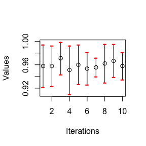

```r
plot(spsaMod, errorBar = TRUE)
```

### Other functions

The `spFSR` package has:

- `getImportance` which returns the importance ranks of best performing features as a `data.frame` object
- `plotImportance` which plots the importance ranks of best performing features
- `getBestModel` which returns the trained or wrapped model based on the set of best performing features.

```r
getImportance(spsaMod)
```

```
#>       features importance
#> 1  Petal.Width    0.76373
#> 2 Petal.Length    0.39640
#> 3  Sepal.Width    0.27386
```

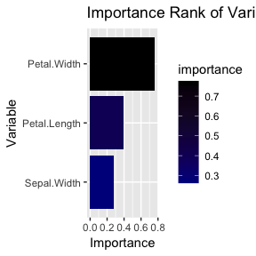

```r
plotImportance(spsaMod)
```

```r
bestMod <- getBestModel(spsaMod)
```

`bestMod` is an object of `WrapperModel` class from the `mlr` package.

```r
class(bestMod)
```

```
#> [1] "WrappedModel"
```

It inherits all methods of this class including `predict`. The `predict` function can be used to predict out-of-sample data using setting `new.data` to a test data. It can be also used to return the predicted responses by incorporating the `task = spsaMod$task.spfs` (which contains only the best performing features). The code chunk below illustrates how predicted responses can be obtained and used to calculate the confusion matrix by calling `calculateConfusionMatrix` from the `mlr` package.

```r
# predict using the best mod
pred <- predict(bestMod, task = spsaMod$task.spfs )

# Obtain confusion matrix
calculateConfusionMatrix( pred )
```

```
#>             predicted
#> true         setosa versicolor virginica -err.-
#>   setosa         49          1         0      1
#>   versicolor      0         48         2      2
#>   virginica       0          2        48      2
#>   -err.-          0          3         2      5
```

## Regression Problem

### Dataset

```r
if( !require(mlbench) ){install.packages('mlbench')}
library(mlbench)
data("BostonHousing")
head(BostonHousing)
```

```
#>      crim zn indus chas   nox    rm  age    dis rad tax ptratio      b
#> 1 0.00632 18  2.31    0 0.538 6.575 65.2 4.0900   1 296    15.3 396.90
#> 2 0.02731  0  7.07    0 0.469 6.421 78.9 4.9671   2 242    17.8 396.90
#> 3 0.02729  0  7.07    0 0.469 7.185 61.1 4.9671   2 242    17.8 392.83
#> 4 0.03237  0  2.18    0 0.458 6.998 45.8 6.0622   3 222    18.7 394.63
#> 5 0.06905  0  2.18    0 0.458 7.147 54.2 6.0622   3 222    18.7 396.90
#> 6 0.02985  0  2.18    0 0.458 6.430 58.7 6.0622   3 222    18.7 394.12
#>   lstat medv
#> 1  4.98 24.0
#> 2  9.14 21.6
#> 3  4.03 34.7
#> 4  2.94 33.4
#> 5  5.33 36.2
#> 6  5.21 28.7
```

### Select features using `spFeatureSelection`

We start configuring a regression task and a linear regression (lm) wrapper:

```r
regTask    <- makeRegrTask(data = BostonHousing,  target = 'medv')
regWrapper <- makeLearner('regr.lm')
```

For a regression problem, stratified sampling is not supported and so `cv.stratify` must be `FALSE`. We use mean squared error (`mse`) to evaluate the linear regression’s performance. Similar to the previous example, we shall run up to 10 iterations by specifying `iters.max = 10` on a single core (`num.cores = 1`).

```r
regSPSA <- spFeatureSelection(
                task = regTask, wrapper = regWrapper,
                measure = mse, num.features.selected = 10,
                cv.stratify = FALSE,
                iters.max = 10,
                num.cores = 1
              )
```

```
#> SPSA-FSR begins:
#> Wrapper = lm
#> Measure = mse
#> Number of selected features = 10
#>
#> iter  value   st.dev  num.ft  best.value
#> 1     30.35112 3.1887  10      30.35112 *
#> 2     23.95179 5.18505 10      23.95179 *
#> 3     24.049  5.92193 10      23.95179
#> 4     23.89387 6.01074 10      23.89387 *
#> 5     24.21654 4.77767 10      23.89387
#> 6     24.43404 5.5683  10      23.89387
#> 7     24.13086 7.23643 10      23.89387
#> 8     24.2094 6.5276  10      23.89387
#> 9     24.15275 5.18024 10      23.89387
#> 10    24.06778 7.16643 10      23.89387
#>
#> Best iteration = 4
#> Number of selected features = 10
#> Best measure value = 23.89387
#> Std. dev. of best measure = 6.01074
#> Run time = 0.15 minutes.
```

### Methods and functions

The methods and importance functions can be also used for regression problems.

```r
summary(regSPSA)
```

```
#> $target
#> [1] "medv"
#>
#> $importance
#>    features importance
#> 1       nox    1.00000
#> 2      crim    0.95513
#> 3        rm    0.77840
#> 4        zn    0.70200
#> 5       dis    0.56367
#> 6      chas    0.50852
#> 7   ptratio    0.47328
#> 8       tax    0.38742
#> 9     lstat    0.37512
#> 10      rad    0.37019
#>
#> $nfeatures
#> [1] 10
#>
#> $niters
#> [1] 10
#>
#> $name
#> [1] "Simple Linear Regression"
#>
#> $best.iter
#> [1] 4
#>
#> $best.value
#> [1] 23.89387
#>
#> $best.std
#> [1] 6.01074
#>
#> attr(,"class")
#> [1] "summary.spFSR"
```

```r
getImportance(regSPSA)
```

```
#>    features importance
#> 1       nox    1.00000
#> 2      crim    0.95513
#> 3        rm    0.77840
#> 4        zn    0.70200
#> 5       dis    0.56367
#> 6      chas    0.50852
#> 7   ptratio    0.47328
#> 8       tax    0.38742
#> 9     lstat    0.37512
#> 10      rad    0.37019
```

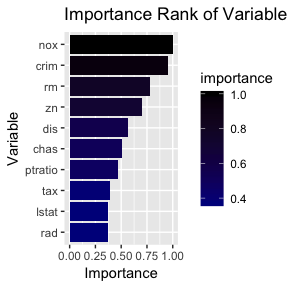

```r
plotImportance(regSPSA)
```

The importance plot reveals nox and crim to be two most important features in predicting the median housing value. We can also obtain the best model via `getBestModel` and make predictions.

```r
bestRegMod <- getBestModel(regSPSA)
predData   <- predict(bestRegMod, task = regSPSA$task.spfs) # obtain the prediction
```

# Summary

Leveraging on the `mlr` package, the `spFSR` package implements the SPSA-FSR Algorithm for feature selection. Given a wrapper, the `spFSR` package can determine a subset of features which predicts the response variable while optimising a specified performance measure.

# References

Aksakalli, Vural, and Milad Malekipirbazari. 2016. “Feature Selection via Binary Simultaneous Perturbation Stochastic Approximation.” *Pattern Recognition Letters*, no. 75. Elsevier B.V.: 41–47.

Barzilai, J., and J. Borwein. 1988. “Two-Point Step Size Gradient Methods.” *IMA Journal of Numerical Analysis*.

Spall, James C. 1992. “Multivariate Stochastic Approximation Using a Simultaneous Perturbation Gradient Approximation.” *IEEE Transactions on Automatic Control*, no. 37 (March). IEEE: 322–41.

Yenice, Zeren D., Niranjan Adhikari, Yong Kai Wong, Alev Taskin Gumus, Vural Aksakalli, and Babak Abbasi. 2018. “SPSA-FSR: Simultaneous Perturbation Stochastic Approximation for Feature Selection and Ranking.”